# Multivariate Meta-Analysis

UV 9216 General Course in Meta-Analysis

Data Example: Tran et al. (2022)

# Data preparation

## Install and load relevant `R` packages

```r
# Install R packages (if needed)
#install.packages("pacman")
library(pacman)
pacman::p_load(metafor,
               metaSEM)
```

## Data Input and Context

The original meta-analytic data set was published by [Tran et al. (2022)](https://doi.org/10.1037/bul0000359) and contains aggregated data from 146 randomized controlled trials. Among other things, Tran et al. (2022) examined the extent to which mindfulness interventions were successful in promoting participants’ self-reported mindfulness and mental health. For both outcomes (i.e., mindfulness and mental health self-reports), Cohen’s $d$ and the respective sampling variances $v_d$ were calculated. Positive values of $d$ indicated a positive effect of the mindfulness intervention on an outcome.

```r
## Read the data set
data <- read.csv2("Tran-et-al-2022-Data.csv",
                  header = TRUE,
                  dec = ',')

## Subset the data
dat <- data[which(data$MindfulnessIntervention==1),]

## Check the data set
head(dat, 10)
```

```
##    StudyID EffectID           Author Year   N       dmh     vardmh       dmin
## 1        1        1             Agee 2009  43 0.4379165 0.05767818 0.45609858
## 3        2        3         Alsubaie 2018  22 0.7359419 0.07291067 0.11049049
## 5        3        5 Andres-Rodriguez 2019  70 0.5946553 0.03062753 0.67035445
## 7        4        7             Arch 2012 128 0.9778619 0.01680553 0.92619318
## 9        5        9           Asuero 2014  68 0.5973997 0.02086093 0.61353590
## 11       6       11         Atkinson 2014  33 0.4716277 0.03842208 0.73099787
## 13       7       13          Avdagic 2014  51 1.1697444 0.05214776 1.51539413
## 15       8       15          Barrett 2012 102 0.1944479 0.01203795 0.07371803
## 17       9       17           Batink 2013 130 0.8374233 0.01321150 0.87833441
## 19      10       19           Bedard 2014 105 0.4222847 0.01946274 0.28989469
##       vardmin MindfulnessIntervention ActiveControl TAUcontrol WaitlistControl
## 1  0.05810594                       1             0          0               0
## 3  0.09146401                       1             0          0               0
## 5  0.04223060                       1             0          0               0
```

[output cut: 40 more lines]

```r
colnames(dat)
```

```
##  [1] "StudyID"                 "EffectID"
##  [3] "Author"                  "Year"
##  [5] "N"                       "dmh"
##  [7] "vardmh"                  "dmin"
##  [9] "vardmin"                 "MindfulnessIntervention"
## [11] "ActiveControl"           "TAUcontrol"
## [13] "WaitlistControl"         "PsychiatricSample"
## [15] "NonpsychiatricSample"    "MedicalSample"
## [17] "TreatmentGroup"          "ControlGroup"
## [19] "TreatmentDuration"       "StudyQuality"
## [21] "MindfulnessMeasure"      "RoB1"
## [23] "RoB2"                    "RoB3"
## [25] "RoB4"                    "RoB5"
## [27] "RoBt"
```

```r
## Number of effect sizes
nrow(dat)
```

```
## [1] 146
```

```r
## Primary studies
table(dat$StudyID)
```

```
##
##   1   2   3   4   5   6   7   8   9  10  11  12  13  14  15  16  17  18  19  20
##   1   1   1   1   1   1   1   1   1   1   1   1   1   1   1   1   1   1   1   1
##  21  22  23  24  25  26  27  28  29  30  31  32  33  34  35  36  37  38  39  40
##   1   1   1   1   1   1   1   1   1   1   1   1   1   1   1   1   1   1   1   1
##  41  42  43  44  45  46  47  48  49  50  51  52  53  54  55  56  57  58  59  60
##   1   1   1   1   1   1   1   1   1   1   1   1   1   1   1   1   1   1   1   1
##  61  62  63  64  65  66  67  68  69  70  71  72  73  74  75  76  77  78  79  80
##   1   1   1   1   1   1   1   1   1   1   1   1   1   1   1   1   1   1   1   1
##  81  82  83  84  85  86  87  88  89  90  91  92  93  94  95  96  97  98  99 100
##   1   1   1   1   1   1   1   1   1   1   1   1   1   1   1   1   1   1   1   1
## 101 102 103 104 105 106 107 108 109 110 111 112 113 114 115 116 117 118 119 120
##   1   1   1   1   1   1   1   1   1   1   1   1   1   1   1   1   1   1   1   1
## 121 122 123 124 125 126 127 128 129 130 131 132 133 134 135 136 137 138 139 140
##   1   1   1   1   1   1   1   1   1   1   1   1   1   1   1   1   1   1   1   1
## 141 142 143 144 145 146
##   1   1   1   1   1   1
```

```r
length(table(dat$StudyID))
```

```
## [1] 146
```

```r
## Overall sample size
sum(dat$N)
```

```
## [1] 10979
```

This data set contains the following identifiers:

- `EffectID`: Identifier of the effect size
- `StudyID`: Identifier is the primary study

# Multivariate Meta-Analysis

In the following sections, we estimate the multivariate models. The original meta-analysis did not include the correlations between mindfulness and mental health self-reports or the effect sizes thereof ($d_{min}$ and $d_{mh}$). Given prior meta-analytic evidence (Xu et al., 2023, https://doi.org/10.3389/fpsyg.2023.994205), we assumed a correlation of $\rho_{min, mh}$=0.35 and calculated the sampling covariance as $SD_{min} \times SD_{mh} \times \rho_{min, mh}$. We strongly suggest conducting sensitivity analyses on the choice of this correlation.

## Multivariate random-effects model

```r
## Calculate the sampling covariance matrix
rho <- 0.35
dat$SampCov <- sqrt(dat$vardmh)*sqrt(dat$vardmin)*rho

## Model estimation
MVREM <- metaSEM::meta(y = cbind(dmh, dmin),
                       v = cbind(vardmh, SampCov, vardmin),
                       data = dat,
                       model.name = "Multivariate REM")

MVREM <- metaSEM::rerun(MVREM)
```

```r
## Model summary
summary.meta(MVREM)
```

```
##
## Call:
## metaSEM::meta(y = cbind(dmh, dmin), v = cbind(vardmh, SampCov,
##     vardmin), data = dat, model.name = "Multivariate REM")
##
## 95% confidence intervals: z statistic approximation (robust=FALSE)
## Coefficients:
##            Estimate Std.Error   lbound   ubound z value  Pr(>|z|)
## Intercept1 0.554217  0.027767 0.499795 0.608639 19.9596 < 2.2e-16 ***
## Intercept2 0.512777  0.028414 0.457087 0.568466 18.0468 < 2.2e-16 ***
## Tau2_1_1   0.077740  0.013328 0.051618 0.103861  5.8330 5.445e-09 ***
## Tau2_2_1   0.047061  0.010507 0.026467 0.067654  4.4789 7.502e-06 ***
## Tau2_2_2   0.075858  0.013382 0.049629 0.102087  5.6685 1.440e-08 ***
## ---
## Signif. codes:  0 '***' 0.001 '**' 0.01 '*' 0.05 '.' 0.1 ' ' 1
##
## Q statistic on the homogeneity of effect sizes: 1021.141
## Degrees of freedom of the Q statistic: 290
## P value of the Q statistic: 0
##
## Heterogeneity indices (based on the estimated Tau2):
##                              Estimate
## Intercept1: I2 (Q statistic)   0.7718
## Intercept2: I2 (Q statistic)   0.7221
##
## Number of studies (or clusters): 146
## Number of observed statistics: 292
## Number of estimated parameters: 5
## Degrees of freedom: 287
## -2 log likelihood: 164.4047
## OpenMx status1: 0 ("0" or "1": The optimization is considered fine.
## Other values may indicate problems.)
```

```r
## Variance-covariance matrix of the random effects
metaSEM::VarCorr(MVREM)
```

```
##            [,1]       [,2]
## [1,] 0.07773962 0.04706063
## [2,] 0.04706063 0.07585827
```

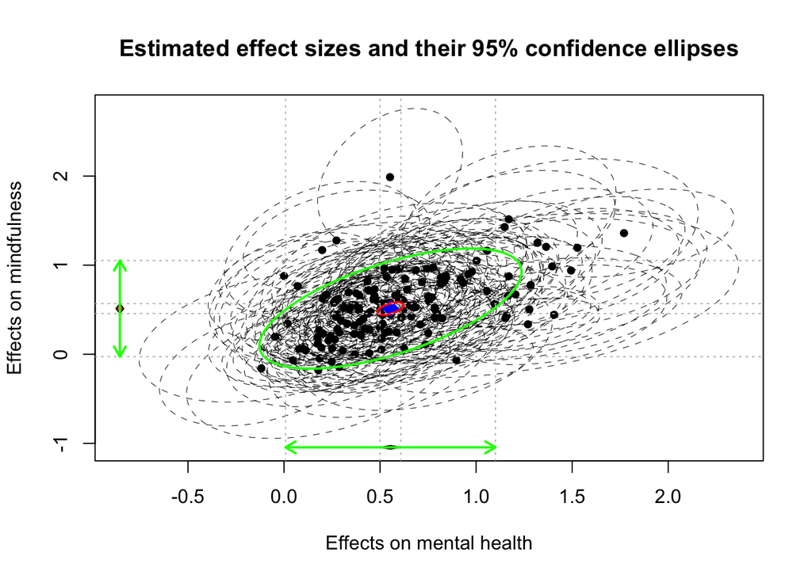

```r
## Plot the multivariate effect sizes
plot(MVREM,
     main="Estimated effect sizes and their 95% confidence ellipses",
     axis.label=c("Effects on mental health",
                  "Effects on mindfulness"))
```

Next, we test several hypotheses on the `MVREM`. First, we test against null effects. Second, we test against a fixed-effects model with zero heterogeneity between RCTs.

## Multivariate random-effects model assuming null effects

```r
## Model estimation
MVREM0 <- metaSEM::meta(y = cbind(dmh, dmin),
                        v = cbind(vardmh, SampCov, vardmin),
                        data = dat,
                        model.name = "Multivariate REM Null Effects",
                        intercept.constraints = matrix(0, nrow=1, ncol=2))

MVREM0 <- metaSEM::rerun(MVREM0)
```

```r
## Model summary
summary.meta(MVREM0)
```

```
##
## Call:
## metaSEM::meta(y = cbind(dmh, dmin), v = cbind(vardmh, SampCov,
##     vardmin), data = dat, intercept.constraints = matrix(0, nrow = 1,
##     ncol = 2), model.name = "Multivariate REM Null Effects")
##
## 95% confidence intervals: z statistic approximation (robust=FALSE)
## Coefficients:
##          Estimate Std.Error   lbound   ubound z value  Pr(>|z|)
## Tau2_1_1 0.402118  0.052385 0.299445 0.504791  7.6762 1.643e-14 ***
## Tau2_2_1 0.345140  0.046012 0.254958 0.435322  7.5011 6.328e-14 ***
## Tau2_2_2 0.349701  0.046950 0.257681 0.441720  7.4484 9.437e-14 ***
## ---
## Signif. codes:  0 '***' 0.001 '**' 0.01 '*' 0.05 '.' 0.1 ' ' 1
##
## Q statistic on the homogeneity of effect sizes: 1021.141
## Degrees of freedom of the Q statistic: 290
## P value of the Q statistic: 0
##
## Heterogeneity indices (based on the estimated Tau2):
##                              Estimate
## Intercept1: I2 (Q statistic)   0.9459
## Intercept2: I2 (Q statistic)   0.9230
##
## Number of studies (or clusters): 146
## Number of observed statistics: 292
## Number of estimated parameters: 3
## Degrees of freedom: 289
## -2 log likelihood: 380.9413
## OpenMx status1: 0 ("0" or "1": The optimization is considered fine.
## Other values may indicate problems.)
```

```r
## Variance-covariance matrix of the random effects
metaSEM::VarCorr(MVREM0)
```

```
##           [,1]      [,2]
## [1,] 0.4021179 0.3451398
## [2,] 0.3451398 0.3497007
```

```r
## Model comparison
anova(MVREM, MVREM0)
```

```
##               base                    comparison ep minus2LL  df      AIC
## 1 Multivariate REM                          <NA>  5 164.4047 287 174.4047
## 2 Multivariate REM Multivariate REM Null Effects  3 380.9413 289 386.9413
##     diffLL diffdf            p
## 1       NA     NA           NA
## 2 216.5366      2 9.542828e-48
```

The null model (`MVREM0`) fits the data significantly worse than the model freely estimating the pooled effects (`MVREM`). We can assume that the effects are different from null effects.

## Multivariate fixed-effects model

```r
## Model estimation
MVFEM <- metaSEM::meta(y = cbind(dmh, dmin),
                       v = cbind(vardmh, SampCov, vardmin),
                       data = dat,
                       model.name = "Multivariate FEM",
                       RE.constraints = matrix(0, ncol=2, nrow=2))

MVFEM <- metaSEM::rerun(MVFEM)
```

```r
## Model summary
summary.meta(MVFEM)
```

```
##
## Call:
## metaSEM::meta(y = cbind(dmh, dmin), v = cbind(vardmh, SampCov,
##     vardmin), data = dat, RE.constraints = matrix(0, ncol = 2,
##     nrow = 2), model.name = "Multivariate FEM")
##
## 95% confidence intervals: z statistic approximation (robust=FALSE)
## Coefficients:
##            Estimate Std.Error   lbound   ubound z value  Pr(>|z|)
## Intercept1 0.463825  0.012493 0.439340 0.488310  37.128 < 2.2e-16 ***
## Intercept2 0.421650  0.014076 0.394061 0.449238  29.955 < 2.2e-16 ***
## ---
## Signif. codes:  0 '***' 0.001 '**' 0.01 '*' 0.05 '.' 0.1 ' ' 1
##
## Q statistic on the homogeneity of effect sizes: 1021.141
## Degrees of freedom of the Q statistic: 290
## P value of the Q statistic: 0
##
## Heterogeneity indices (based on the estimated Tau2):
##                              Estimate
## Intercept1: I2 (Q statistic)        0
## Intercept2: I2 (Q statistic)        0
##
## Number of studies (or clusters): 146
## Number of observed statistics: 292
## Number of estimated parameters: 2
## Degrees of freedom: 290
## -2 log likelihood: 550.0529
## OpenMx status1: 0 ("0" or "1": The optimization is considered fine.
## Other values may indicate problems.)
```

```r
## Model comparison
anova(MVREM, MVFEM)
```

```
##               base       comparison ep minus2LL  df      AIC   diffLL diffdf
## 1 Multivariate REM             <NA>  5 164.4047 287 174.4047       NA     NA
## 2 Multivariate REM Multivariate FEM  2 550.0529 290 554.0529 385.6482      3
##              p
## 1           NA
## 2 2.842562e-83
```

The fixed-effects model (`MVFEM`) fits the data significantly worse than the random-effects model (`MVREM`). We can assume heterogeneity across RCTs.

## Mixed-Effects Multivariate Meta-Analysis: Moderation by the Risk of Bias

We extend the multivariate REM to a mixed-effects meta-regression model by adding a risk of bias score as a moderator. In this example, we chose to represent the risk of bias by a sum score.

### Plots of the Relations between Risk of Bias and Effect Sizes

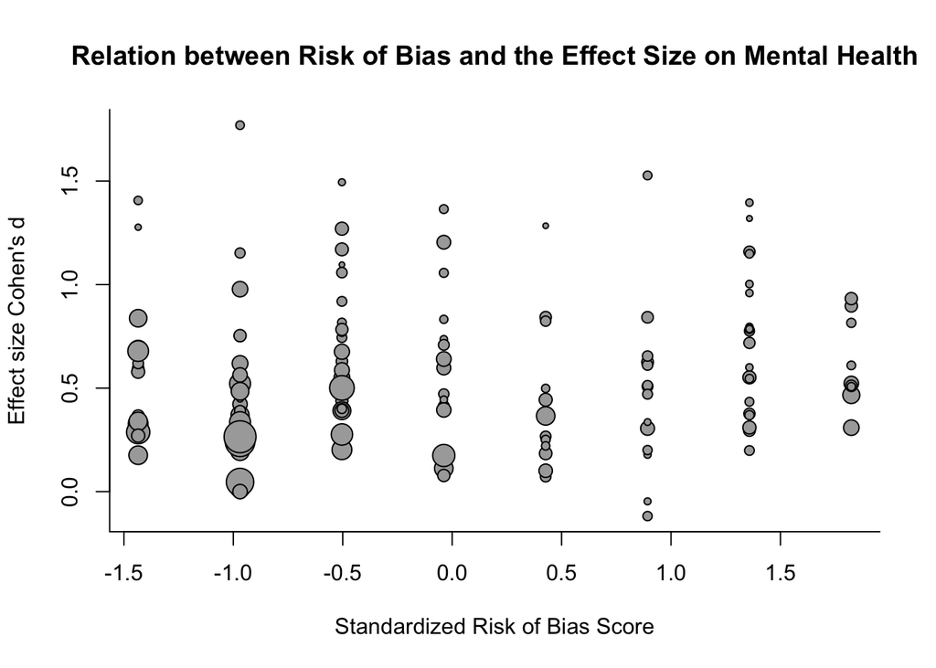

```r
## Create the sum score
dat$RoBsum <- dat$RoB1+dat$RoB2+dat$RoB3+dat$RoB4+dat$RoB5
dat$zRoBsum <- scale(dat$RoBsum, center = T, scale = T)

## Source: https://www.metafor-project.org/doku.php/tips:non_linear_meta_regression

## Plots quality against the effect size
plot(x = dat$zRoBsum,
     y = dat$dmh,
     ylab = "Effect size Cohen's d",
     xlab = "Standardized Risk of Bias Score",
     main = "Relation between Risk of Bias and the Effect Size on Mental Health",
     pch = 21,
     col = "black",
     bg = "darkgray",
     cex = .20/sqrt(dat$vardmh),
     bty = "l")
```

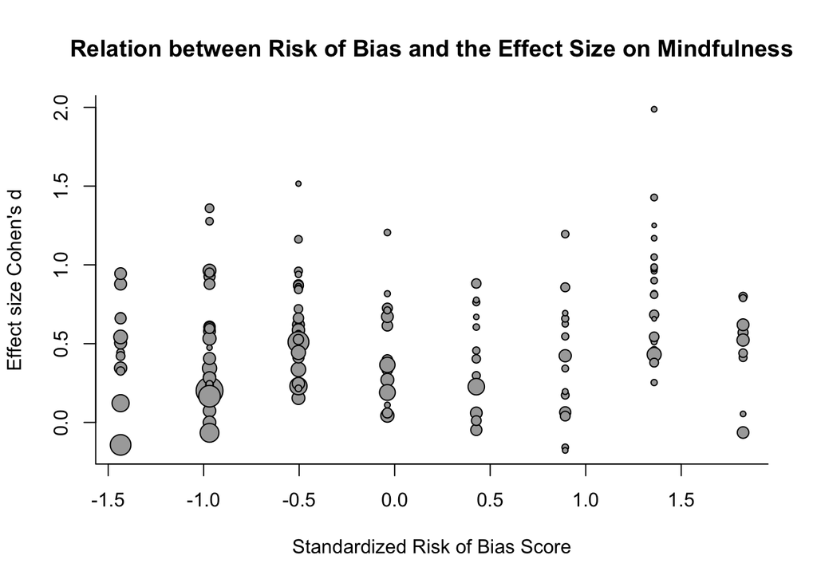

```r
plot(x = dat$zRoBsum,
     y = dat$dmin,
     ylab = "Effect size Cohen's d",
     xlab = "Standardized Risk of Bias Score",
     main = "Relation between Risk of Bias and the Effect Size on Mindfulness",
     pch = 21,
     col = "black",
     bg = "darkgray",
     cex = .20/sqrt(dat$vardmin),
     bty = "l")
```

```r
##dev.off()
```

### Linear Moderator Effects

```r
## Model estimation
MVMEM.linear <- metaSEM::meta(y = cbind(dmh, dmin),
                              v = cbind(vardmh, SampCov, vardmin),
                              data = dat,
                              x = dat$zRoBsum,
                              R2 = TRUE,
                              model.name = "Linear moderator effects")

MVMEM.linear <- metaSEM::rerun(MVMEM.linear)
```

```r
## Model summary
summary.meta(MVMEM.linear)
```

```
##
## Call:
## metaSEM::meta(y = cbind(dmh, dmin), v = cbind(vardmh, SampCov,
##     vardmin), x = dat$zRoBsum, data = dat, R2 = TRUE, model.name = "Linear moderator effects")
##
## 95% confidence intervals: z statistic approximation (robust=FALSE)
## Coefficients:
##             Estimate Std.Error    lbound    ubound z value  Pr(>|z|)
## Intercept1  0.555967  0.027664  0.501746  0.610188 20.0969 < 2.2e-16 ***
## Intercept2  0.514535  0.028433  0.458808  0.570262 18.0966 < 2.2e-16 ***
## Slope1_1    0.029412  0.027647 -0.024775  0.083599  1.0638    0.2874
## Slope2_1    0.026396  0.028545 -0.029552  0.082344  0.9247    0.3551
## Tau2_1_1    0.076556  0.013231  0.050625  0.102488  5.7862 7.199e-09 ***
## Tau2_2_1    0.046130  0.010429  0.025690  0.066570  4.4233 9.722e-06 ***
## Tau2_2_2    0.075249  0.013306  0.049169  0.101329  5.6551 1.557e-08 ***
## ---
## Signif. codes:  0 '***' 0.001 '**' 0.01 '*' 0.05 '.' 0.1 ' ' 1
##
## Q statistic on the homogeneity of effect sizes: 1021.141
## Degrees of freedom of the Q statistic: 290
## P value of the Q statistic: 0
##
## Explained variances (R2):
##                              y1     y2
## Tau2 (no predictor)    0.077740 0.0759
## Tau2 (with predictors) 0.076556 0.0752
## R2                     0.015220 0.0080
##
## Number of studies (or clusters): 146
## Number of observed statistics: 292
## Number of estimated parameters: 7
## Degrees of freedom: 285
## -2 log likelihood: 163.0965
## OpenMx status1: 0 ("0" or "1": The optimization is considered fine.
## Other values may indicate problems.)
```

```r
## Model estimation assuming equal moderator effects across effects
MVMEM.linear.eq <- metaSEM::meta(y = cbind(dmh, dmin),
                              v = cbind(vardmh, SampCov, vardmin),
                              data = dat,
                              x = dat$zRoBsum,
                              R2 = TRUE,
                              coef.constraints = matrix(c("0.0*eq_mod_effect",
                                                          "0.0*eq_mod_effect"),
                                                        nrow=2),
                              model.name = "Equal linear moderator effects")

MVMEM.linear.eq <- metaSEM::rerun(MVMEM.linear.eq)
```

```r
## Model summary
summary.meta(MVMEM.linear.eq)
```

```
##
## Call:
## metaSEM::meta(y = cbind(dmh, dmin), v = cbind(vardmh, SampCov,
##     vardmin), x = dat$zRoBsum, data = dat, coef.constraints = matrix(c("0.0*eq_mod_effect",
##     "0.0*eq_mod_effect"), nrow = 2), R2 = TRUE, model.name = "Equal linear moderator effects")
##
## 95% confidence intervals: z statistic approximation (robust=FALSE)
## Coefficients:
##                Estimate Std.Error    lbound    ubound z value  Pr(>|z|)
## Intercept1     0.555837  0.027642  0.501659  0.610015 20.1081 < 2.2e-16 ***
## Intercept2     0.514738  0.028375  0.459124  0.570351 18.1407 < 2.2e-16 ***
## eq_mod_effect  0.028005  0.024522 -0.020056  0.076067  1.1421    0.2534
## Tau2_1_1       0.076579  0.013232  0.050646  0.102513  5.7876 7.139e-09 ***
## Tau2_2_1       0.046114  0.010428  0.025674  0.066553  4.4219 9.783e-06 ***
## Tau2_2_2       0.075264  0.013309  0.049178  0.101349  5.6549 1.559e-08 ***
## ---
## Signif. codes:  0 '***' 0.001 '**' 0.01 '*' 0.05 '.' 0.1 ' ' 1
##
## Q statistic on the homogeneity of effect sizes: 1021.141
## Degrees of freedom of the Q statistic: 290
## P value of the Q statistic: 0
##
## Explained variances (R2):
##                              y1     y2
## Tau2 (no predictor)    0.077740 0.0759
## Tau2 (with predictors) 0.076579 0.0753
## R2                     0.014924 0.0078
##
## Number of studies (or clusters): 146
## Number of observed statistics: 292
## Number of estimated parameters: 6
## Degrees of freedom: 286
## -2 log likelihood: 163.1086
## OpenMx status1: 0 ("0" or "1": The optimization is considered fine.
## Other values may indicate problems.)
```

```r
## Model comparison
anova(MVMEM.linear, MVMEM.linear.eq)
```

```
##                       base                     comparison ep minus2LL  df
## 1 Linear moderator effects                           <NA>  7 163.0965 285
## 2 Linear moderator effects Equal linear moderator effects  6 163.1086 286
##        AIC     diffLL diffdf         p
## 1 177.0965         NA     NA        NA
## 2 175.1086 0.01210697      1 0.9123843
```

The model suggests that there is no evidence for a significant and linear moderation by the risk of bias score. Given the model comparisons, the linear moderator effects can be assumed to be equal for the effects on mental health and mindfulness.